# Lab 5

Vista Sohrab

9/21/2020

```r
library(tidyverse)
library(lubridate)
```

## Lab Exercises

1. Data Visualization can be found in lab 4a: Data Visualization with ggplot2.
2. Obtain June 13, 2020 dataframe from JHU COVID-19 dashboard daily reports, and then filter to only include US data, while grouping by US states to identify the total confirmed COVID-19 cases for each US state.

```r
Confirmed_State_6_13 <-   read_csv(url("https://raw.githubusercontent.com/CSSEGISandData/COVID-19/master/csse_covid_19_data/csse_covid_19_daily_reports/06-13-2020.csv")) %>%
  filter (Country_Region == "US") %>%
  group_by(Province_State, Country_Region) %>%
  summarise(Confirmed = sum(Confirmed))
str(Confirmed_State_6_13)
```

[output not shown]

[output cut: 12 more lines]

[output not shown]

Similarly, obtain the September 13, 2020 dataframe. Filter by country to include US COVID-19 data, and then group by US states to identify the total number of confirmed cases for each US state.

```r
Confirmed_State_9_13 <-   read_csv(url("https://raw.githubusercontent.com/CSSEGISandData/COVID-19/master/csse_covid_19_data/csse_covid_19_daily_reports/09-13-2020.csv")) %>%
  filter (Country_Region == "US") %>%
  group_by(Province_State, Country_Region) %>%
  summarise(Confirmed = sum(Confirmed))
str(Confirmed_State_9_13)
```

[output not shown]

[output cut: 12 more lines]

[output not shown]

Join the June 13 and September 13 tables together using a full outer join.

```r
Confirmed_State_6_13_9_13_joined <- full_join(Confirmed_State_6_13,
      Confirmed_State_9_13, by = c("Province_State"))

head(Confirmed_State_6_13_9_13_joined)
```

```
## # A tibble: 6 x 5
## # Groups:   Province_State [6]
##   Province_State Country_Region.x Confirmed.x Country_Region.y Confirmed.y
##   <chr>          <chr>                  <dbl> <chr>                  <dbl>
## 1 Alabama        US                     24601 US                    138755
## 2 Alaska         US                       653 US                      6268
## 3 Arizona        US                     34660 US                    208512
## 4 Arkansas       US                     12095 US                     70219
## 5 California     US                    150018 US                    761728
## 6 Colorado       US                     29002 US                     61293
```

In the resulting full outer join table using the state as a key, confirmed columns are renamed to indicate the corresponding month and date which they belong to while the country is removed since the original data frame had been filtered to include only US observations.

```r
Confirmed_State_6_13_9_13_joined <- full_join(Confirmed_State_6_13,
      Confirmed_State_9_13, by = c("Province_State")) %>%
      rename(Confirmed_6_13_2020 = "Confirmed.x", Confirmed_9_13_2020 = "Confirmed.y") %>%
      select(-Country_Region.x, -Country_Region.y)

head(Confirmed_State_6_13_9_13_joined)
```

```
## # A tibble: 6 x 3
## # Groups:   Province_State [6]
##   Province_State Confirmed_6_13_2020 Confirmed_9_13_2020
##   <chr>                        <dbl>               <dbl>
## 1 Alabama                      24601              138755
## 2 Alaska                         653                6268
## 3 Arizona                      34660              208512
## 4 Arkansas                     12095               70219
## 5 California                  150018              761728
## 6 Colorado                     29002               61293
```

```r
tail(Confirmed_State_6_13_9_13_joined)
```

```
## # A tibble: 6 x 3
## # Groups:   Province_State [6]
##   Province_State Confirmed_6_13_2020 Confirmed_9_13_2020
##   <chr>                        <dbl>               <dbl>
## 1 Virgin Islands                  72                1220
## 2 Virginia                     53869              133742
## 3 Washington                   25538               79826
## 4 West Virginia                 2274               12705
## 5 Wisconsin                    22518               89185
## 6 Wyoming                       1050                4346
```

```r
#check that there are no NA values
which(is.na(Confirmed_State_6_13_9_13_joined))
```

```
## integer(0)
```

Using pivot_longer to switch to long table format and removing “Recovered” from full outer join result:

```r
Confirmed_State_6_13_9_13_joined_long <- Confirmed_State_6_13_9_13_joined %>%
              filter(Province_State != "Recovered") %>%
              pivot_longer(-c(Province_State),
                            names_to = "Date", values_to = "Confirmed")

head(Confirmed_State_6_13_9_13_joined_long)
```

```
## # A tibble: 6 x 3
## # Groups:   Province_State [3]
##   Province_State Date                Confirmed
##   <chr>          <chr>                   <dbl>
## 1 Alabama        Confirmed_6_13_2020     24601
## 2 Alabama        Confirmed_9_13_2020    138755
## 3 Alaska         Confirmed_6_13_2020       653
## 4 Alaska         Confirmed_9_13_2020      6268
## 5 Arizona        Confirmed_6_13_2020     34660
## 6 Arizona        Confirmed_9_13_2020    208512
```

### Barplot showing confirmed cases for both dates:

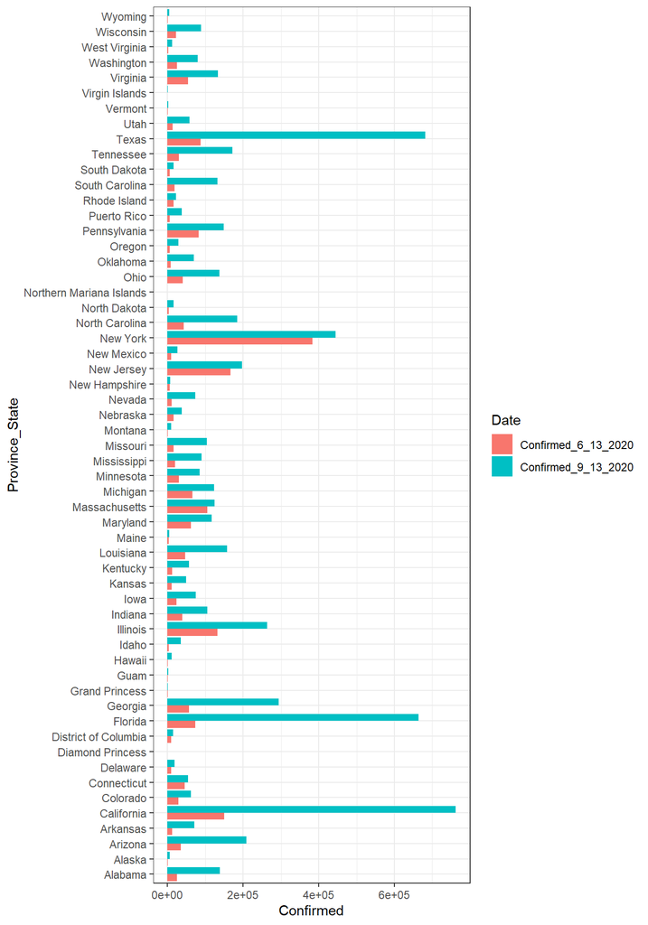

```r
confirmed_bar <- ggplot(Confirmed_State_6_13_9_13_joined_long, aes(x = Confirmed, y = Province_State))+
  geom_bar(aes(fill = Date),stat="identity", position = "dodge") +
    theme_bw()

confirmed_bar
```

3. Adding axes labels and title to previous bar plot:

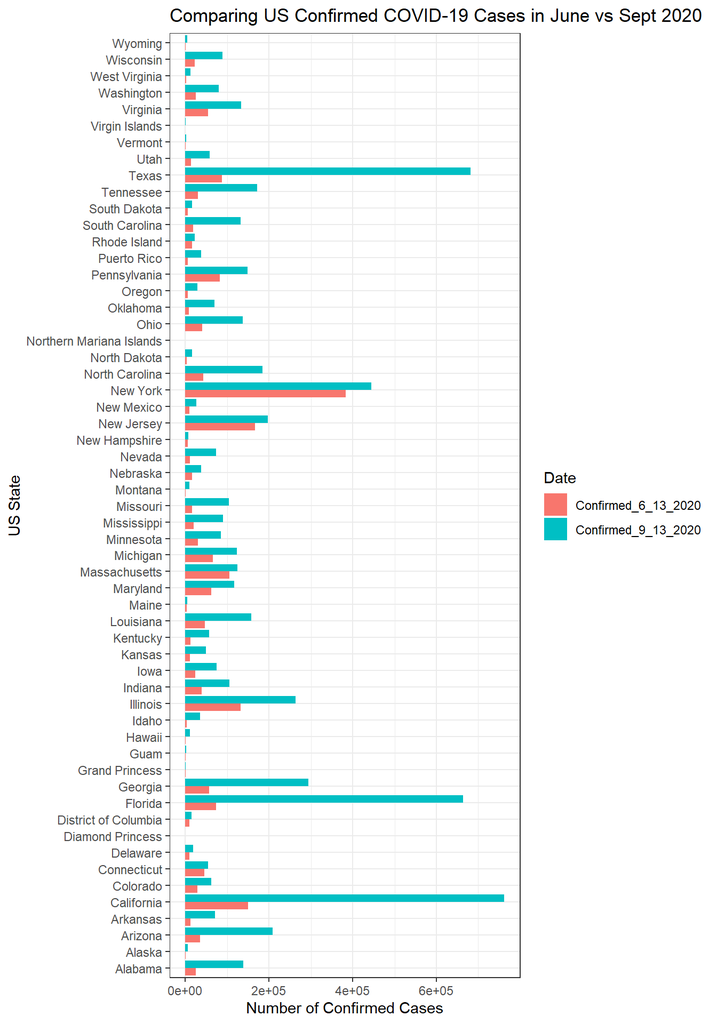

```r
confirmed_bar +
  labs(x = 'Number of Confirmed Cases',
       y = 'US State',
       title = 'Comparing US Confirmed COVID-19 Cases in June vs Sept 2020')
```

## Time Series Data

Time series for confirmed COVID-19 cases:

```r
#Data Wrangling
time_series_confirmed <- read_csv(url("https://raw.githubusercontent.com/CSSEGISandData/COVID-19/master/csse_covid_19_data/csse_covid_19_time_series/time_series_covid19_confirmed_global.csv")) %>%
rename(Province_State = "Province/State", Country_Region = "Country/Region")
head(time_series_confirmed)
```

```
## # A tibble: 6 x 250
##   Province_State Country_Region   Lat   Long `1/22/20` `1/23/20` `1/24/20`
##   <chr>          <chr>          <dbl>  <dbl>     <dbl>     <dbl>     <dbl>
## 1 <NA>           Afghanistan     33.9  67.7          0         0         0
## 2 <NA>           Albania         41.2  20.2          0         0         0
## 3 <NA>           Algeria         28.0   1.66         0         0         0
## 4 <NA>           Andorra         42.5   1.52         0         0         0
## 5 <NA>           Angola         -11.2  17.9          0         0         0
## 6 <NA>           Antigua and B~  17.1 -61.8          0         0         0
## # ... with 243 more variables: `1/25/20` <dbl>, `1/26/20` <dbl>,
## #   `1/27/20` <dbl>, `1/28/20` <dbl>, `1/29/20` <dbl>, `1/30/20` <dbl>,
## #   `1/31/20` <dbl>, `2/1/20` <dbl>, `2/2/20` <dbl>, `2/3/20` <dbl>,
## #   `2/4/20` <dbl>, `2/5/20` <dbl>, `2/6/20` <dbl>, `2/7/20` <dbl>,
## #   `2/8/20` <dbl>, `2/9/20` <dbl>, `2/10/20` <dbl>, `2/11/20` <dbl>,
## #   `2/12/20` <dbl>, `2/13/20` <dbl>, `2/14/20` <dbl>, `2/15/20` <dbl>,
## #   `2/16/20` <dbl>, `2/17/20` <dbl>, `2/18/20` <dbl>, `2/19/20` <dbl>,
## #   `2/20/20` <dbl>, `2/21/20` <dbl>, `2/22/20` <dbl>, `2/23/20` <dbl>,
## #   `2/24/20` <dbl>, `2/25/20` <dbl>, `2/26/20` <dbl>, `2/27/20` <dbl>,
## #   `2/28/20` <dbl>, `2/29/20` <dbl>, `3/1/20` <dbl>, `3/2/20` <dbl>,
## #   `3/3/20` <dbl>, `3/4/20` <dbl>, `3/5/20` <dbl>, `3/6/20` <dbl>,
## #   `3/7/20` <dbl>, `3/8/20` <dbl>, `3/9/20` <dbl>, `3/10/20` <dbl>,
## #   `3/11/20` <dbl>, `3/12/20` <dbl>, `3/13/20` <dbl>, `3/14/20` <dbl>,
## #   `3/15/20` <dbl>, `3/16/20` <dbl>, `3/17/20` <dbl>, `3/18/20` <dbl>,
## #   `3/19/20` <dbl>, `3/20/20` <dbl>, `3/21/20` <dbl>, `3/22/20` <dbl>,
## #   `3/23/20` <dbl>, `3/24/20` <dbl>, `3/25/20` <dbl>, `3/26/20` <dbl>,
## #   `3/27/20` <dbl>, `3/28/20` <dbl>, `3/29/20` <dbl>, `3/30/20` <dbl>,
## #   `3/31/20` <dbl>, `4/1/20` <dbl>, `4/2/20` <dbl>, `4/3/20` <dbl>,
## #   `4/4/20` <dbl>, `4/5/20` <dbl>, `4/6/20` <dbl>, `4/7/20` <dbl>,
## #   `4/8/20` <dbl>, `4/9/20` <dbl>, `4/10/20` <dbl>, `4/11/20` <dbl>,
## #   `4/12/20` <dbl>, `4/13/20` <dbl>, `4/14/20` <dbl>, `4/15/20` <dbl>,
## #   `4/16/20` <dbl>, `4/17/20` <dbl>, `4/18/20` <dbl>, `4/19/20` <dbl>,
## #   `4/20/20` <dbl>, `4/21/20` <dbl>, `4/22/20` <dbl>, `4/23/20` <dbl>,
## #   `4/24/20` <dbl>, `4/25/20` <dbl>, `4/26/20` <dbl>, `4/27/20` <dbl>,
## #   `4/28/20` <dbl>, `4/29/20` <dbl>, `4/30/20` <dbl>, `5/1/20` <dbl>,
## #   `5/2/20` <dbl>, `5/3/20` <dbl>, ...
```

```r
dim(time_series_confirmed)
```

```
## [1] 266 250
```

Converting time series confirmed data from wide to long:

```r
time_series_confirmed_long <- time_series_confirmed %>%
               pivot_longer(-c(Province_State, Country_Region, Lat, Long),
                            names_to = "Date", values_to = "Confirmed")

dim(time_series_confirmed_long)
```

```
## [1] 65436     6
```

```r
head(time_series_confirmed_long)
```

```
## # A tibble: 6 x 6
##   Province_State Country_Region   Lat  Long Date    Confirmed
##   <chr>          <chr>          <dbl> <dbl> <chr>       <dbl>
## 1 <NA>           Afghanistan     33.9  67.7 1/22/20         0
## 2 <NA>           Afghanistan     33.9  67.7 1/23/20         0
## 3 <NA>           Afghanistan     33.9  67.7 1/24/20         0
## 4 <NA>           Afghanistan     33.9  67.7 1/25/20         0
## 5 <NA>           Afghanistan     33.9  67.7 1/26/20         0
## 6 <NA>           Afghanistan     33.9  67.7 1/27/20         0
```

```r
tail(time_series_confirmed_long)
```

```
## # A tibble: 6 x 6
##   Province_State Country_Region   Lat  Long Date    Confirmed
##   <chr>          <chr>          <dbl> <dbl> <chr>       <dbl>
## 1 <NA>           Zimbabwe       -19.0  29.2 9/18/20      7647
## 2 <NA>           Zimbabwe       -19.0  29.2 9/19/20      7672
## 3 <NA>           Zimbabwe       -19.0  29.2 9/20/20      7683
## 4 <NA>           Zimbabwe       -19.0  29.2 9/21/20      7683
## 5 <NA>           Zimbabwe       -19.0  29.2 9/22/20      7711
## 6 <NA>           Zimbabwe       -19.0  29.2 9/23/20      7725
```

Time series data for COVID-19 deaths:

```r
time_series_deaths <- read_csv(url("https://raw.githubusercontent.com/CSSEGISandData/COVID-19/master/csse_covid_19_data/csse_covid_19_time_series/time_series_covid19_deaths_global.csv"))%>%
  rename(Province_State = "Province/State", Country_Region = "Country/Region")
dim(time_series_deaths)
```

```
## [1] 266 250
```

Converting time series death data frame from wide to long:

```r
time_series_deaths_long <- time_series_deaths %>%
               pivot_longer(-c(Province_State, Country_Region, Lat, Long),
                            names_to = "Date", values_to = "Deaths")
dim(time_series_deaths_long)
```

```
## [1] 65436     6
```

```r
head(time_series_deaths_long)
```

```
## # A tibble: 6 x 6
##   Province_State Country_Region   Lat  Long Date    Deaths
##   <chr>          <chr>          <dbl> <dbl> <chr>    <dbl>
## 1 <NA>           Afghanistan     33.9  67.7 1/22/20      0
## 2 <NA>           Afghanistan     33.9  67.7 1/23/20      0
## 3 <NA>           Afghanistan     33.9  67.7 1/24/20      0
## 4 <NA>           Afghanistan     33.9  67.7 1/25/20      0
## 5 <NA>           Afghanistan     33.9  67.7 1/26/20      0
## 6 <NA>           Afghanistan     33.9  67.7 1/27/20      0
```

```r
tail(time_series_deaths_long)
```

```
## # A tibble: 6 x 6
##   Province_State Country_Region   Lat  Long Date    Deaths
##   <chr>          <chr>          <dbl> <dbl> <chr>    <dbl>
## 1 <NA>           Zimbabwe       -19.0  29.2 9/18/20    224
## 2 <NA>           Zimbabwe       -19.0  29.2 9/19/20    225
## 3 <NA>           Zimbabwe       -19.0  29.2 9/20/20    225
## 4 <NA>           Zimbabwe       -19.0  29.2 9/21/20    225
## 5 <NA>           Zimbabwe       -19.0  29.2 9/22/20    226
## 6 <NA>           Zimbabwe       -19.0  29.2 9/23/20    227
```

Creating keys to join the two tables and removing columns from deaths dataframe that is already present in the confirmed data frame:

```r
time_series_confirmed_long <- time_series_confirmed_long %>%
  unite(Key, Province_State, Country_Region, Date, sep = ".", remove = FALSE)

head(time_series_confirmed_long)
```

```
## # A tibble: 6 x 7
##   Key                 Province_State Country_Region   Lat  Long Date   Confirmed
##   <chr>               <chr>          <chr>          <dbl> <dbl> <chr>      <dbl>
## 1 NA.Afghanistan.1/2~ <NA>           Afghanistan     33.9  67.7 1/22/~         0
## 2 NA.Afghanistan.1/2~ <NA>           Afghanistan     33.9  67.7 1/23/~         0
## 3 NA.Afghanistan.1/2~ <NA>           Afghanistan     33.9  67.7 1/24/~         0
## 4 NA.Afghanistan.1/2~ <NA>           Afghanistan     33.9  67.7 1/25/~         0
## 5 NA.Afghanistan.1/2~ <NA>           Afghanistan     33.9  67.7 1/26/~         0
## 6 NA.Afghanistan.1/2~ <NA>           Afghanistan     33.9  67.7 1/27/~         0
```

```r
time_series_deaths_long <- time_series_deaths_long %>%
  unite(Key, Province_State, Country_Region, Date, sep = ".") %>%
  select(Key, Deaths)
```

Peforming a full outer join on confirmed and deaths dataframe using the created key and removing it since unnecessary thereafter.

```r
time_series_long_joined <- full_join(time_series_confirmed_long,
              time_series_deaths_long, by = c("Key")) %>%
              select(-Key)

head(time_series_long_joined)
```

```
## # A tibble: 6 x 7
##   Province_State Country_Region   Lat  Long Date    Confirmed Deaths
##   <chr>          <chr>          <dbl> <dbl> <chr>       <dbl>  <dbl>
## 1 <NA>           Afghanistan     33.9  67.7 1/22/20         0      0
## 2 <NA>           Afghanistan     33.9  67.7 1/23/20         0      0
## 3 <NA>           Afghanistan     33.9  67.7 1/24/20         0      0
## 4 <NA>           Afghanistan     33.9  67.7 1/25/20         0      0
## 5 <NA>           Afghanistan     33.9  67.7 1/26/20         0      0
## 6 <NA>           Afghanistan     33.9  67.7 1/27/20         0      0
```

Verifying that there are no NAs in the deaths and confirmed columns in the data frame obtained above:

```r
which(is.na(time_series_long_joined$Confirmed))
```

```
## integer(0)
```

```r
which(is.na(time_series_long_joined$Deaths))
```

```
## integer(0)
```

Reformatting dates:

```r
time_series_long_joined$Date <- mdy(time_series_long_joined$Date)
head(time_series_long_joined)
```

```
## # A tibble: 6 x 7
##   Province_State Country_Region   Lat  Long Date       Confirmed Deaths
##   <chr>          <chr>          <dbl> <dbl> <date>         <dbl>  <dbl>
## 1 <NA>           Afghanistan     33.9  67.7 2020-01-22         0      0
## 2 <NA>           Afghanistan     33.9  67.7 2020-01-23         0      0
## 3 <NA>           Afghanistan     33.9  67.7 2020-01-24         0      0
## 4 <NA>           Afghanistan     33.9  67.7 2020-01-25         0      0
## 5 <NA>           Afghanistan     33.9  67.7 2020-01-26         0      0
## 6 <NA>           Afghanistan     33.9  67.7 2020-01-27         0      0
```

Forming columns called Report_Type that take values of ‘Confirmed’ or ‘Death’ and their respective counts for a particular country, province, latitude, longitude and date.

```r
time_series_long_joined_counts <- time_series_long_joined %>%
  pivot_longer(-c(Province_State, Country_Region, Lat, Long, Date),
               names_to = "Report_Type", values_to = "Counts")
head(time_series_long_joined_counts)
```

```
## # A tibble: 6 x 7
##   Province_State Country_Region   Lat  Long Date       Report_Type Counts
##   <chr>          <chr>          <dbl> <dbl> <date>     <chr>        <dbl>
## 1 <NA>           Afghanistan     33.9  67.7 2020-01-22 Confirmed        0
## 2 <NA>           Afghanistan     33.9  67.7 2020-01-22 Deaths           0
## 3 <NA>           Afghanistan     33.9  67.7 2020-01-23 Confirmed        0
## 4 <NA>           Afghanistan     33.9  67.7 2020-01-23 Deaths           0
## 5 <NA>           Afghanistan     33.9  67.7 2020-01-24 Confirmed        0
## 6 <NA>           Afghanistan     33.9  67.7 2020-01-24 Deaths           0
```

4. Plot of the total number of confirmed deaths per day worldwide using time series data.

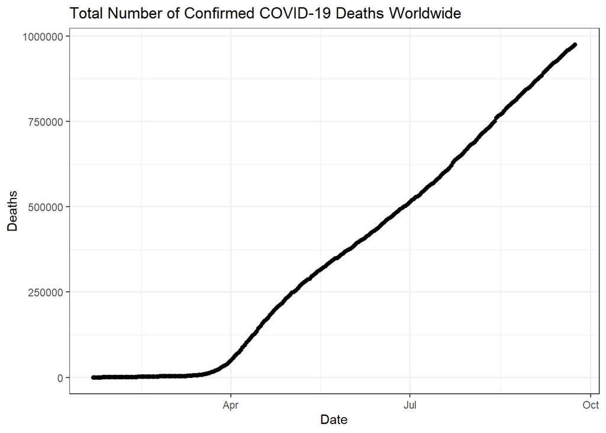

```r
time_series_long_joined %>%
  group_by(Date) %>%
  summarise_at(c("Confirmed", "Deaths"), sum) %>%
    ggplot(aes(x = Date,  y = Deaths)) +
    geom_point() +
    geom_line() +
    ggtitle("Total Number of Confirmed COVID-19 Deaths Worldwide")+
    theme_bw()
```

5. Making a new column with deaths per confirmed ratio:

```r
time_series_ratio <- mutate(time_series_long_joined, ratio = Deaths/Confirmed)
head(time_series_ratio)
```

```
## # A tibble: 6 x 8
##   Province_State Country_Region   Lat  Long Date       Confirmed Deaths ratio
##   <chr>          <chr>          <dbl> <dbl> <date>         <dbl>  <dbl> <dbl>
## 1 <NA>           Afghanistan     33.9  67.7 2020-01-22         0      0   NaN
## 2 <NA>           Afghanistan     33.9  67.7 2020-01-23         0      0   NaN
## 3 <NA>           Afghanistan     33.9  67.7 2020-01-24         0      0   NaN
## 4 <NA>           Afghanistan     33.9  67.7 2020-01-25         0      0   NaN
## 5 <NA>           Afghanistan     33.9  67.7 2020-01-26         0      0   NaN
## 6 <NA>           Afghanistan     33.9  67.7 2020-01-27         0      0   NaN
```

```r
tail(time_series_ratio)
```

```
## # A tibble: 6 x 8
##   Province_State Country_Region   Lat  Long Date       Confirmed Deaths  ratio
##   <chr>          <chr>          <dbl> <dbl> <date>         <dbl>  <dbl>  <dbl>
## 1 <NA>           Zimbabwe       -19.0  29.2 2020-09-18      7647    224 0.0293
## 2 <NA>           Zimbabwe       -19.0  29.2 2020-09-19      7672    225 0.0293
## 3 <NA>           Zimbabwe       -19.0  29.2 2020-09-20      7683    225 0.0293
## 4 <NA>           Zimbabwe       -19.0  29.2 2020-09-21      7683    225 0.0293
## 5 <NA>           Zimbabwe       -19.0  29.2 2020-09-22      7711    226 0.0293
## 6 <NA>           Zimbabwe       -19.0  29.2 2020-09-23      7725    227 0.0294
```

6. Plot US deaths/confirmed cases per day.

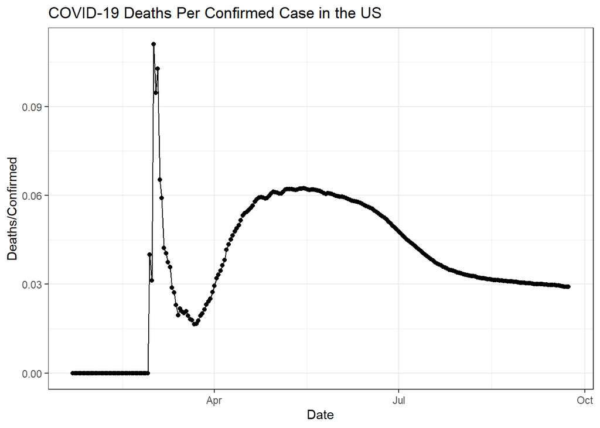

```r
time_series_ratio %>%
  filter(Country_Region == "US") %>%
  ggplot(aes(x = Date, y = ratio)) +
  geom_point()+
  geom_line()+
  ggtitle("COVID-19 Deaths Per Confirmed Case in the US")+
  xlab("Date")+
  ylab("Deaths/Confirmed")+
  theme_bw()
```

7. Make a single graph from the times series data with the 10 countries with the highest death total.

```r
top10_countries <- time_series_long_joined %>%
    group_by(Country_Region, Date) %>%
    summarise(Total_Deaths = sum(Deaths))%>%
    filter(Date == "2020-09-22") %>%
    arrange(desc(Total_Deaths)) %>%
    head(n=10)
top10_countries
```

```
## # A tibble: 10 x 3
## # Groups:   Country_Region [10]
##    Country_Region Date       Total_Deaths
##    <chr>          <date>            <dbl>
##  1 US             2020-09-22       200786
##  2 Brazil         2020-09-22       138105
##  3 India          2020-09-22        88935
##  4 Mexico         2020-09-22        74348
##  5 United Kingdom 2020-09-22        41914
##  6 Italy          2020-09-22        35738
##  7 France         2020-09-22        31426
##  8 Peru           2020-09-22        31369
##  9 Spain          2020-09-22        30904
## 10 Iran           2020-09-22        24656
```

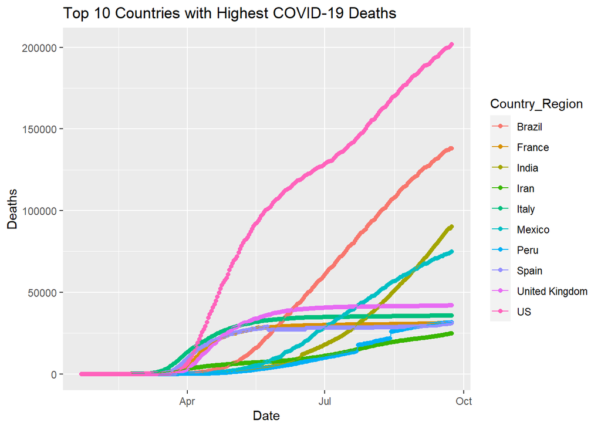

```r
time_series_long_joined %>%
    group_by(Country_Region,Date) %>%
    summarise_at(c("Confirmed", "Deaths"), sum) %>%
    filter (Country_Region %in% top10_countries$Country_Region) %>%
    ggplot(aes(x = Date,  y = Deaths, color = Country_Region)) +
    geom_point() +
    geom_line() +
    ggtitle("Top 10 Countries with Highest COVID-19 Deaths")
```

8. Using Facet_Wraps make a graph from the times series data with the 10 countries with the highest death total.

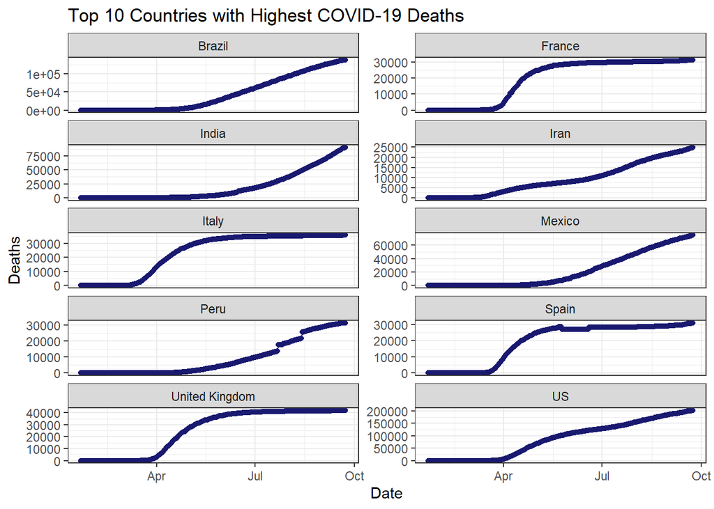

```r
time_series_long_joined %>%
    group_by(Country_Region,Date) %>%
    summarise_at(c("Confirmed", "Deaths"), sum) %>%
    filter (Country_Region %in% top10_countries$Country_Region) %>%
    ggplot(aes(x = Date,  y = Deaths)) +
    geom_point(color="midnightblue") +
    geom_line(color="midnightblue") +
    facet_wrap(. ~ Country_Region, ncol= 2, scale = "free_y")+
    theme_bw()+
    ggtitle("Top 10 Countries with Highest COVID-19 Deaths")
```

9. Using Facet_Wraps make a graph from the times series data for confirmed cases for all US states and territories.

Obtaining US states confirmed cases data:

```r
time_series_confirmed_csv <- download.file(url="https://raw.githubusercontent.com/CSSEGISandData/COVID-19/master/csse_covid_19_data/csse_covid_19_time_series/time_series_covid19_confirmed_US.csv",
               destfile = "data/time_series_covid19_confirmed_US.csv")
```

```r
time_series_confirmed_US <- read_csv("data/time_series_covid19_confirmed_US.csv")
head(time_series_confirmed_US)
```

```
## # A tibble: 6 x 256
##      UID iso2  iso3  code3  FIPS Admin2 Province_State Country_Region   Lat
##    <dbl> <chr> <chr> <dbl> <dbl> <chr>  <chr>          <chr>          <dbl>
## 1 8.40e7 US    USA     840  1001 Autau~ Alabama        US              32.5
## 2 8.40e7 US    USA     840  1003 Baldw~ Alabama        US              30.7
## 3 8.40e7 US    USA     840  1005 Barbo~ Alabama        US              31.9
## 4 8.40e7 US    USA     840  1007 Bibb   Alabama        US              33.0
## 5 8.40e7 US    USA     840  1009 Blount Alabama        US              34.0
## 6 8.40e7 US    USA     840  1011 Bullo~ Alabama        US              32.1
## # ... with 247 more variables: Long_ <dbl>, Combined_Key <chr>,
## #   `1/22/20` <dbl>, `1/23/20` <dbl>, `1/24/20` <dbl>, `1/25/20` <dbl>,
## #   `1/26/20` <dbl>, `1/27/20` <dbl>, `1/28/20` <dbl>, `1/29/20` <dbl>,
## #   `1/30/20` <dbl>, `1/31/20` <dbl>, `2/1/20` <dbl>, `2/2/20` <dbl>,
## #   `2/3/20` <dbl>, `2/4/20` <dbl>, `2/5/20` <dbl>, `2/6/20` <dbl>,
## #   `2/7/20` <dbl>, `2/8/20` <dbl>, `2/9/20` <dbl>, `2/10/20` <dbl>,
## #   `2/11/20` <dbl>, `2/12/20` <dbl>, `2/13/20` <dbl>, `2/14/20` <dbl>,
## #   `2/15/20` <dbl>, `2/16/20` <dbl>, `2/17/20` <dbl>, `2/18/20` <dbl>,
## #   `2/19/20` <dbl>, `2/20/20` <dbl>, `2/21/20` <dbl>, `2/22/20` <dbl>,
## #   `2/23/20` <dbl>, `2/24/20` <dbl>, `2/25/20` <dbl>, `2/26/20` <dbl>,
## #   `2/27/20` <dbl>, `2/28/20` <dbl>, `2/29/20` <dbl>, `3/1/20` <dbl>,
## #   `3/2/20` <dbl>, `3/3/20` <dbl>, `3/4/20` <dbl>, `3/5/20` <dbl>,
## #   `3/6/20` <dbl>, `3/7/20` <dbl>, `3/8/20` <dbl>, `3/9/20` <dbl>,
## #   `3/10/20` <dbl>, `3/11/20` <dbl>, `3/12/20` <dbl>, `3/13/20` <dbl>,
## #   `3/14/20` <dbl>, `3/15/20` <dbl>, `3/16/20` <dbl>, `3/17/20` <dbl>,
## #   `3/18/20` <dbl>, `3/19/20` <dbl>, `3/20/20` <dbl>, `3/21/20` <dbl>,
## #   `3/22/20` <dbl>, `3/23/20` <dbl>, `3/24/20` <dbl>, `3/25/20` <dbl>,
## #   `3/26/20` <dbl>, `3/27/20` <dbl>, `3/28/20` <dbl>, `3/29/20` <dbl>,
## #   `3/30/20` <dbl>, `3/31/20` <dbl>, `4/1/20` <dbl>, `4/2/20` <dbl>,
## #   `4/3/20` <dbl>, `4/4/20` <dbl>, `4/5/20` <dbl>, `4/6/20` <dbl>,
## #   `4/7/20` <dbl>, `4/8/20` <dbl>, `4/9/20` <dbl>, `4/10/20` <dbl>,
## #   `4/11/20` <dbl>, `4/12/20` <dbl>, `4/13/20` <dbl>, `4/14/20` <dbl>,
## #   `4/15/20` <dbl>, `4/16/20` <dbl>, `4/17/20` <dbl>, `4/18/20` <dbl>,
## #   `4/19/20` <dbl>, `4/20/20` <dbl>, `4/21/20` <dbl>, `4/22/20` <dbl>,
## #   `4/23/20` <dbl>, `4/24/20` <dbl>, `4/25/20` <dbl>, `4/26/20` <dbl>,
## #   `4/27/20` <dbl>, `4/28/20` <dbl>, ...
```

```r
dim(time_series_confirmed_US)
```

```
## [1] 3340  256
```

```r
#Data wrangling
time_series_confirmed_US_long <- time_series_confirmed_US %>%
   group_by(Province_State) %>%
    pivot_longer(-c(Province_State, Country_Region, Lat, Long_,Admin2, FIPS, code3, iso2, iso3, UID, Combined_Key), names_to = "Date", values_to = "Confirmed")

time_series_confirmed_US_long$Date <- mdy(time_series_confirmed_US_long$Date)

dim(time_series_confirmed_US_long)
```

```
## [1] 818300     13
```

```r
time_series_confirmed_US_long %>%
  select(Admin2, Province_State,Country_Region, Date, Confirmed) %>%
  head()
```

```
## # A tibble: 6 x 5
## # Groups:   Province_State [1]
##   Admin2  Province_State Country_Region Date       Confirmed
##   <chr>   <chr>          <chr>          <date>         <dbl>
## 1 Autauga Alabama        US             2020-01-22         0
## 2 Autauga Alabama        US             2020-01-23         0
## 3 Autauga Alabama        US             2020-01-24         0
## 4 Autauga Alabama        US             2020-01-25         0
## 5 Autauga Alabama        US             2020-01-26         0
## 6 Autauga Alabama        US             2020-01-27         0
```

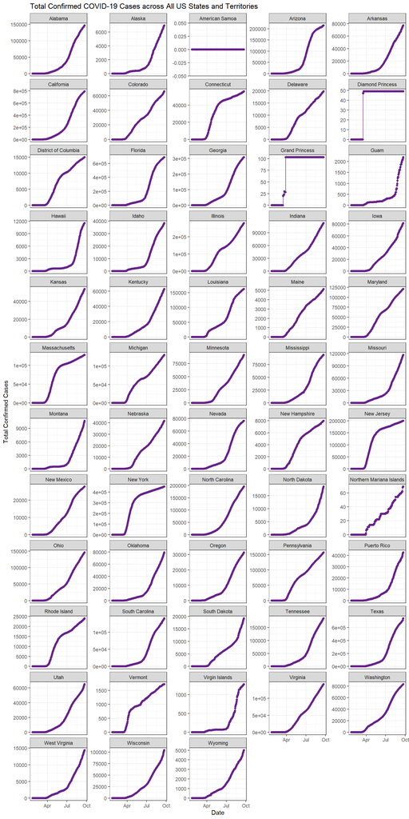

```r
#Plot
time_series_confirmed_US_long %>%
  group_by(Province_State, Date) %>%
  summarise_at("Confirmed", sum) %>%
  ggplot(aes(x = Date,  y = Confirmed))+
   geom_point(color= "darkorchid4") +
   geom_line(color= "darkorchid4") +
   facet_wrap(~Province_State, ncol = 5, scale = "free_y")+
   labs(x = "Date", y = "Total Confirmed Cases", title = "Total Confirmed COVID-19 Cases across All US States and Territories") +
   theme_bw()
```

10. Apply a theme other than the one used in the Data Carpentries tutorial to the graph in Ex8.

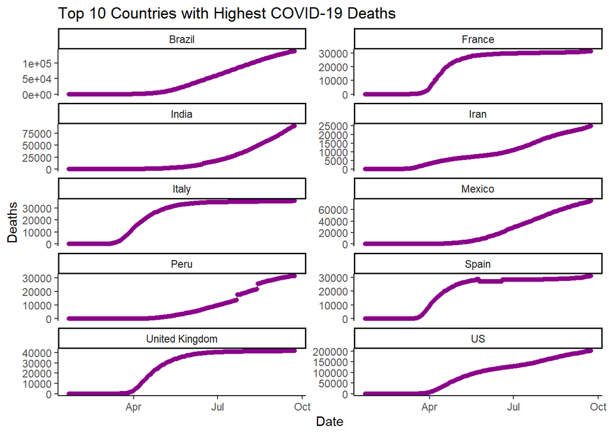

```r
time_series_long_joined %>%
    group_by(Country_Region,Date) %>%
    summarise_at(c("Confirmed", "Deaths"), sum) %>%
    filter (Country_Region %in% top10_countries$Country_Region) %>%
    ggplot(aes(x = Date,  y = Deaths)) +
    geom_point(color="darkmagenta") +
    geom_line(color="darkmagenta") +
    facet_wrap(. ~ Country_Region, ncol= 2, scale = "free_y")+
    theme_classic()+
    ggtitle("Top 10 Countries with Highest COVID-19 Deaths")
```